# Kombucha experiment meets Phyloseq

# Experiment

For seven days, from July 27 to August 2, 2016, I drank 48 ounces per day of commercially-purchased kombucha. I tested my gut microbiome with a uBiome Explorer kit each day, as well as my mouth and skin microbiome at intervals during the experiment.

The results of each uBiome Explorer test are in the data directory in a series of JSON-formatted files.

```r
library(phyloseq)
library(actino)
library(ggplot2)

f <- just_json_files_in(DATA_DIR)  # this variable holds the path to all my JSON files.
m <- paste0(DATA_DIR,'/Richard_Sprague_Mapfile.xlsx')

ps <- phyloseq_from_JSON_at_rank(f,m,rank="genus")
ps.species <- phyloseq_from_JSON_at_rank(f,m,rank="species")
sample_data(ps)$Date <- sapply(lapply(sample_data(ps)[['Date']],
                                                 as.Date,
                                                 origin = "1899-12-30"), # not sure why this origin gives correct answers
                                          as.character)
sample_data(ps.species)$Date <- sapply(lapply(sample_data(ps)[['Date']],
                                                 as.Date,
                                                 origin = "1899-12-30"), # not sure why this origin gives correct answers
                                          as.character)
kombucha <- subset_samples(ps, Site == "gut"  & Date > "2016-07-26"  & Date < "2016-08-09")
kombucha.species <- subset_samples(ps.species, Site == "gut"  & Date > "2016-07-26"  & Date < "2016-08-09")
```

The new object `kombucha` is a phyloseq object. Note that I created two versions, one that looked at the genus rank and the other at species. Both of them contain the same sample data, however:

```r
sample_data(kombucha)[,c(1:4,7)]
```

```
##             Username       Date   SSR Site                     Label
## 73837 RichardSprague 2016-07-27 73837  gut                    0None0
## 73814 RichardSprague 2016-07-28 73814  gut               1 Kombucha1
## 74607 RichardSprague 2016-07-29 74607  gut               2 Kombucha2
## 74573 RichardSprague 2016-07-31 74573  gut            4 Kombucha4 P1
## 74582 RichardSprague 2016-07-31 74582  gut            5 Kombucha4 P2
## 74561 RichardSprague 2016-08-01 74561  gut               6 Kombucha5
## 75657 RichardSprague 2016-08-02 75657  gut               7 Kombucha6
## 75637 RichardSprague 2016-08-03 75637  gut                    8None1
## 75625 RichardSprague 2016-08-04 75625  gut                    ZNone2
## 78351 RichardSprague 2016-08-04 78351  gut                    9None3
## 75519 RichardSprague 2016-08-05 75519  gut            Fiberwell beer
## 74845 RichardSprague 2016-08-06 74845  gut Midnight arrival sandwich
## 74821 RichardSprague 2016-08-07 74821  gut          Liver and onions
## 74847 RichardSprague 2016-08-08 74847  gut            Ribs moon root
```

To simplify later calculations and plotting, let’s add another column (variable) `Experiment` that is set to either “Kombucha” on days I drank it, and “None” on days I didn’t:

```r
sample_data(kombucha)$Experiment <-
  ifelse(grepl("Kombucha",sample_data(kombucha)$Label),"Kombucha","None")
sample_data(kombucha.species)$Experiment <- sample_data(kombucha)$Experiment
```

The data is still raw, containing the un-processed abundance data from the Illumina sequencer. Because there are differences in the way the DNA from the microbes are read in each sample (called “reads”), the total number of reads can vary significantly from sample to sample. For that reason, we generally don’t compare the absolute abundances found in each sample; instead we calculate the percentages. To do that, we first must compute the normalized abundances:

```r
sample_data(kombucha)
```

```
##             Username       Date   SSR Site
## 73837 RichardSprague 2016-07-27 73837  gut
## 73814 RichardSprague 2016-07-28 73814  gut
## 74607 RichardSprague 2016-07-29 74607  gut
## 74573 RichardSprague 2016-07-31 74573  gut
## 74582 RichardSprague 2016-07-31 74582  gut
## 74561 RichardSprague 2016-08-01 74561  gut
## 75657 RichardSprague 2016-08-02 75657  gut
## 75637 RichardSprague 2016-08-03 75637  gut
## 75625 RichardSprague 2016-08-04 75625  gut
## 78351 RichardSprague 2016-08-04 78351  gut
## 75519 RichardSprague 2016-08-05 75519  gut
## 74845 RichardSprague 2016-08-06 74845  gut
## 74821 RichardSprague 2016-08-07 74821  gut
## 74847 RichardSprague 2016-08-08 74847  gut
```

[output cut: 30 more lines]

```r
kombucha.norm <- transform_sample_counts(kombucha, function(x) x / sum(x))

  #transform_sample_counts(prune_taxa(taxa_sums(kombucha) > 10,kombucha), function(x){x / sum(x)})
kombucha.species.norm <- transform_sample_counts(prune_taxa(taxa_sums(kombucha.species) > 10,kombucha.species), function(x){x / sum(x)})
```

# Genus Level Analysis

Now let’s graph it at the genus level:

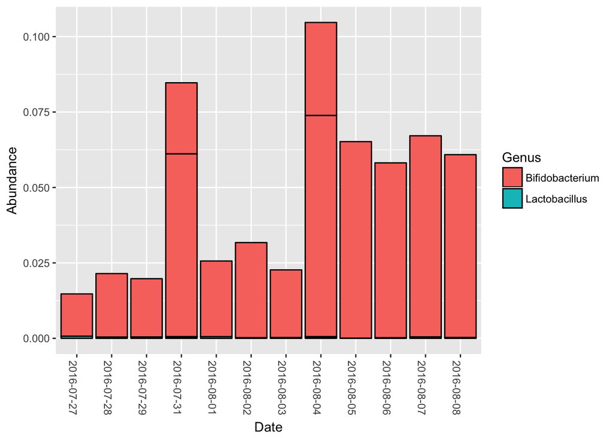

```r
colnames(tax_table(kombucha.norm)) <- c(g = "Genus")

targetTaxa <- c("Bifidobacterium","Lactobacillus")

plot_bar(subset_taxa(kombucha.norm, Genus %in% targetTaxa),
         fill="Genus",
         x="Date")
```

Now let’s cluster the samples

```r
kombucha.ord <- ordinate(kombucha.norm, method = "NMDS", distance = "bray")
```

```
## *** Solution reached
```

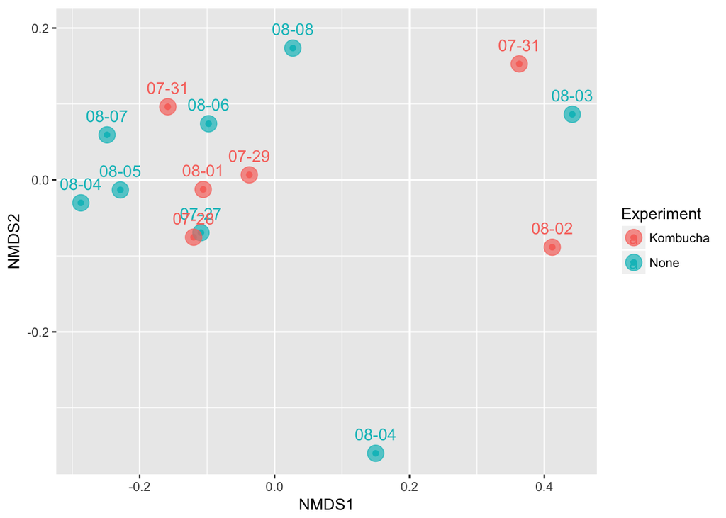

```r
plot_ordination(kombucha.norm, kombucha.ord, color = "Experiment") +
  geom_point(size = 5, alpha = 0.7) + geom_text(aes(label = strftime(Date,format = "%m-%d")),size=4, nudge_y=0.025)
```

and try a heatmap, just looking at the top 20 taxa (in this case at the genus rank);

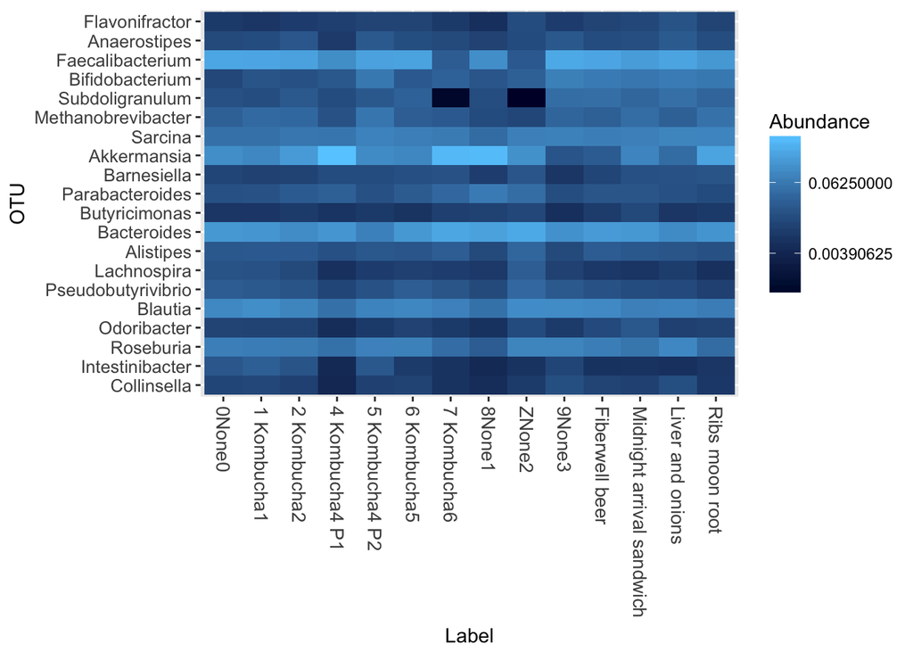

```r
plot_heatmap(prune_taxa(names(sort(taxa_sums(kombucha.norm),TRUE)[1:20]),kombucha.norm), sample.label = "Label", sample.order = "Date")
```

# Diversity

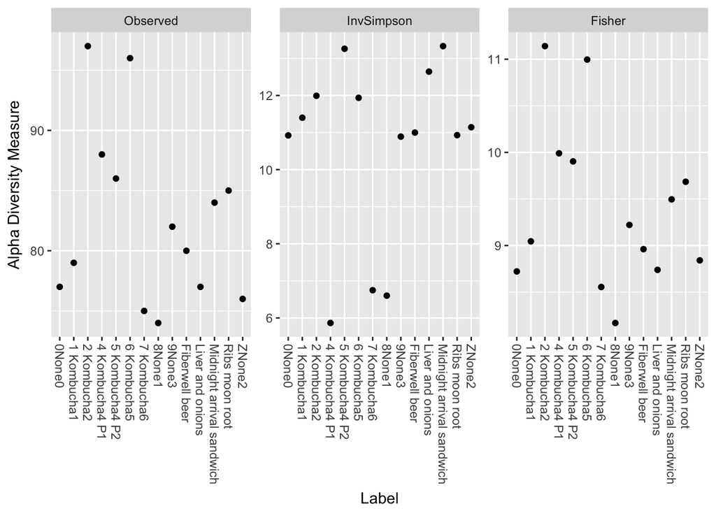

```r
#kombucha.int <- transform_sample_counts(kombucha,function (x) round(x*100))
plot_richness(kombucha,x="Label",measures=c("Observed","InvSimpson","Fisher"))
```

# Species Level Analysis

uBiome’s 16S technology only looks at the V4 subunit, with less than 300 reads in each direction. That’s plenty for most genus and above analysis, but it gets strained at the species level. Still, some of the species *are* visible, so let’s look at the most common ones:

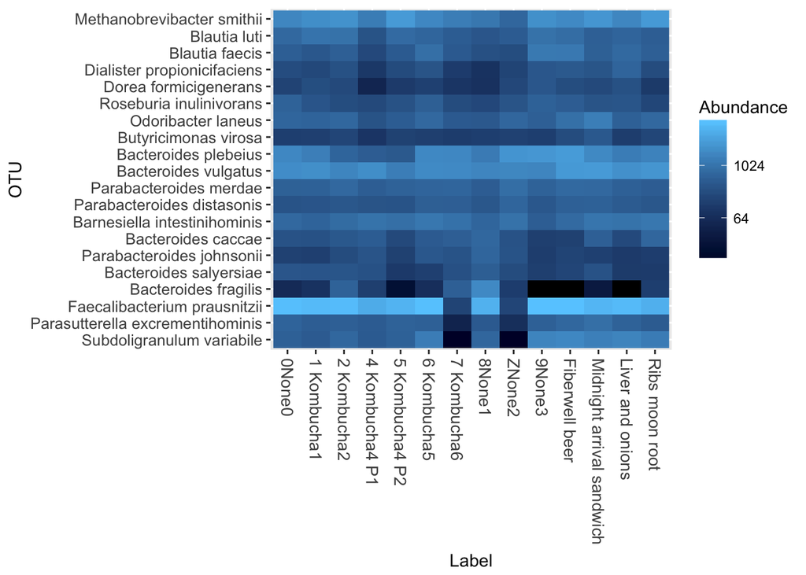

```r
colnames(tax_table(kombucha.species)) <- c(g = "Species")
targetTaxa <- as.character(read.table("targetSpecies.txt", sep="\n")[,1])

plot_heatmap(prune_taxa(names(sort(taxa_sums(kombucha.species),TRUE)[1:20]),kombucha.species), sample.label = "Label", sample.order = "Date")
```

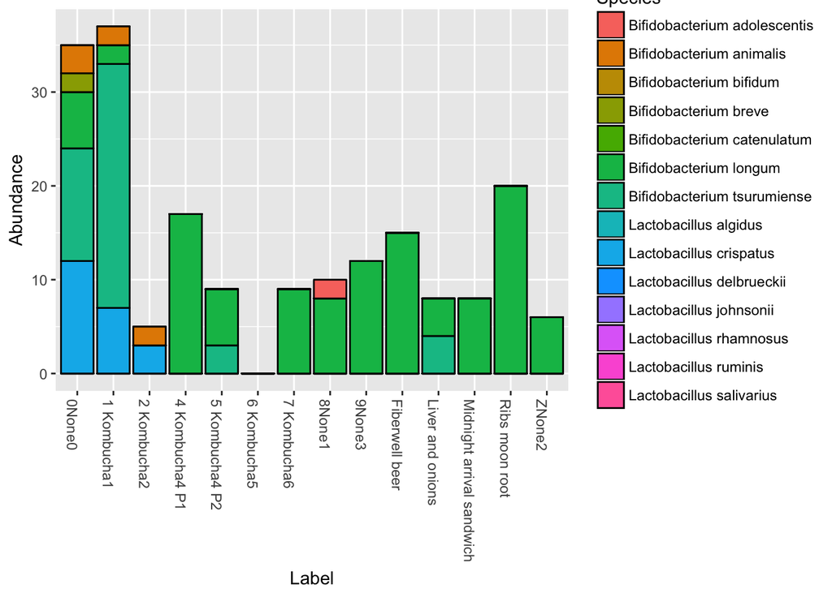

```r
plot_bar(subset_taxa(kombucha.species, Species %in% targetTaxa),
         fill="Species",
         x="Label")
```

Note that because this is species level, this figure differs from genus one above because not every species within the genus is identifiable.